# Homework3

```r
library(MASS)
library(boot)
library(splines)
library(ISLR)
library(tree)
library(randomForest)
library(caret)
library(gbm)
library(e1071)
```

# 1 Week 6 Exercises:

## 1.1 Chapter 7 - Exercise 9

### 1.1.1 Task a)

```r
attach(Boston)

poly.lm = lm(nox ~ poly(dis, 3), data=Boston)
poly.lm.sum = summary(poly.lm)
```

Here is a plot of the data with the fitted cubic polynomial curve.

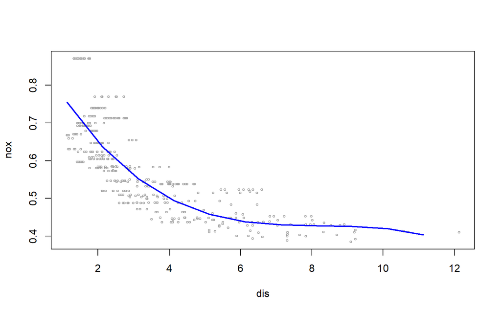

```r
dislims = range(dis)
dis.grid=seq(from=dislims[1], to=dislims[2])
preds = predict(poly.lm, newdata=list(dis = dis.grid), se=TRUE)

plot(dis, nox, xlim=dislims, cex =.5, col="darkgrey")
lines(dis.grid, preds$fit, lwd=2, col="blue")
```

### 1.1.2 Task b)

Here are plots of polynomial fits of degree 1 to 10. The residual sums of squares are at the bottom of each plot.

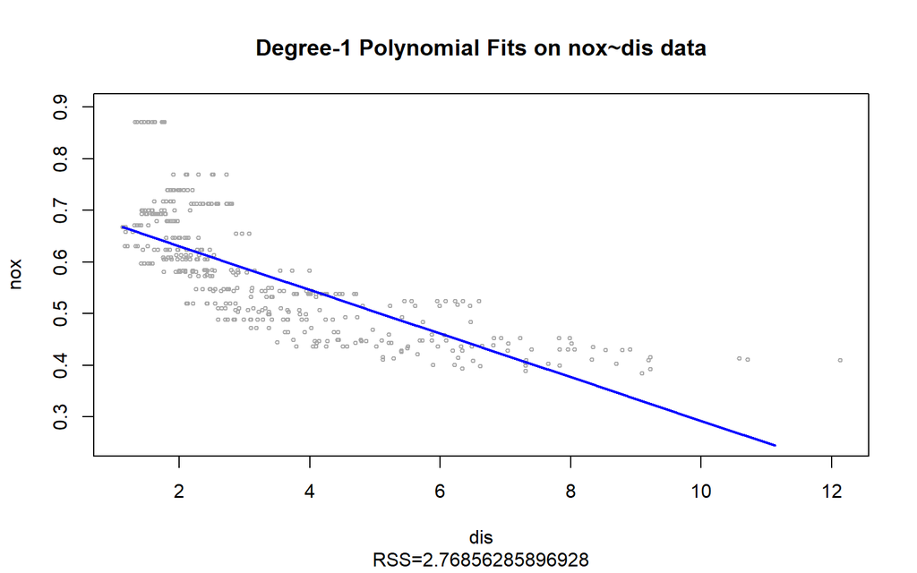

```r
# Degree=1 is done separately so that the fitted curve would be more visible
poly.lm = lm(nox ~ poly(dis, 1), data=Boston)
preds = predict(poly.lm, newdata=list(dis = dis.grid), se=TRUE)
plot(dis, nox, xlim=dislims, ylim=c(.25, .9), cex =.5, col="darkgrey")
title("Degree-1 Polynomial Fits on nox~dis data")
title(sub=paste0("RSS=", sum(poly.lm$residuals^2)))
lines(dis.grid, preds$fit, lwd=2,col="blue")
```

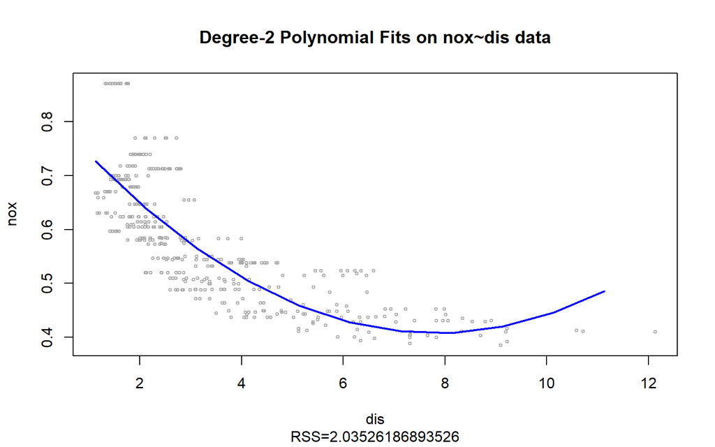

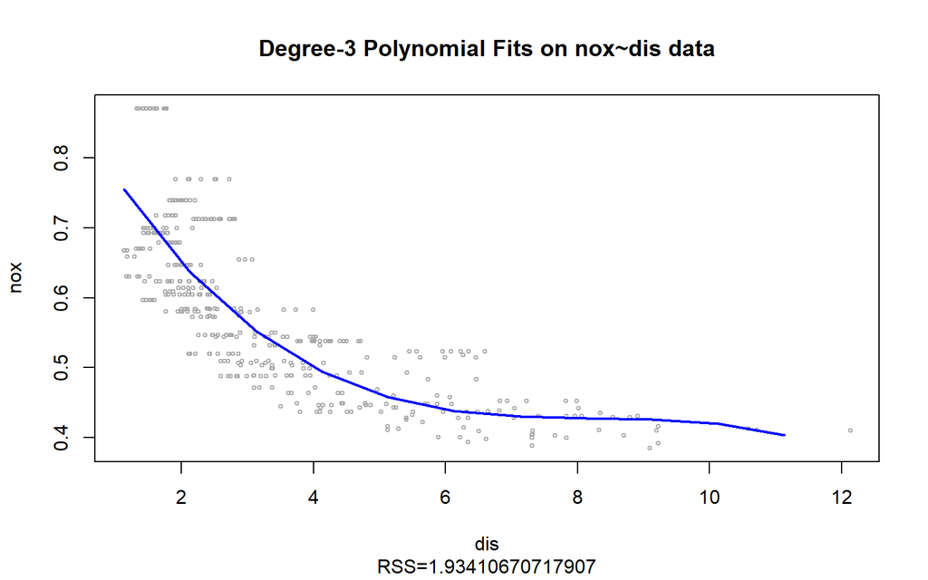

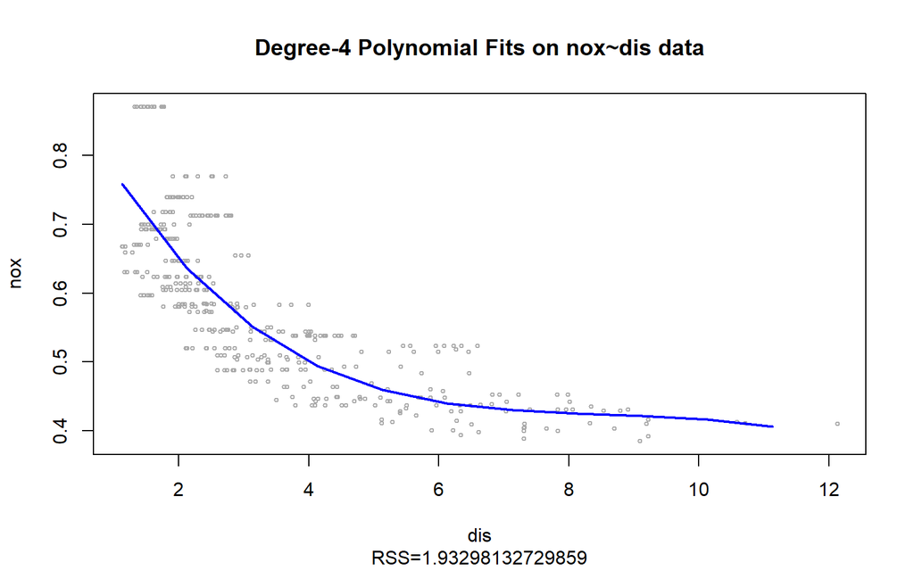

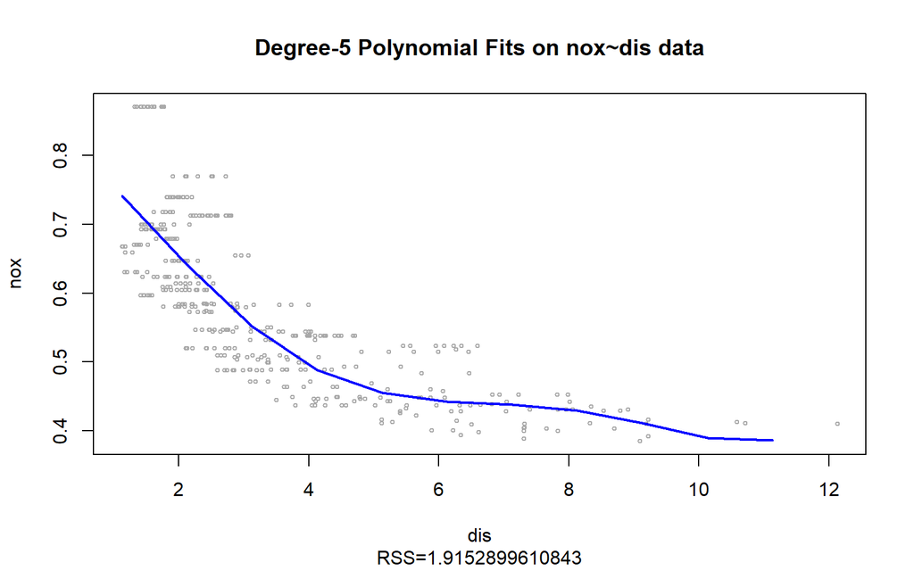

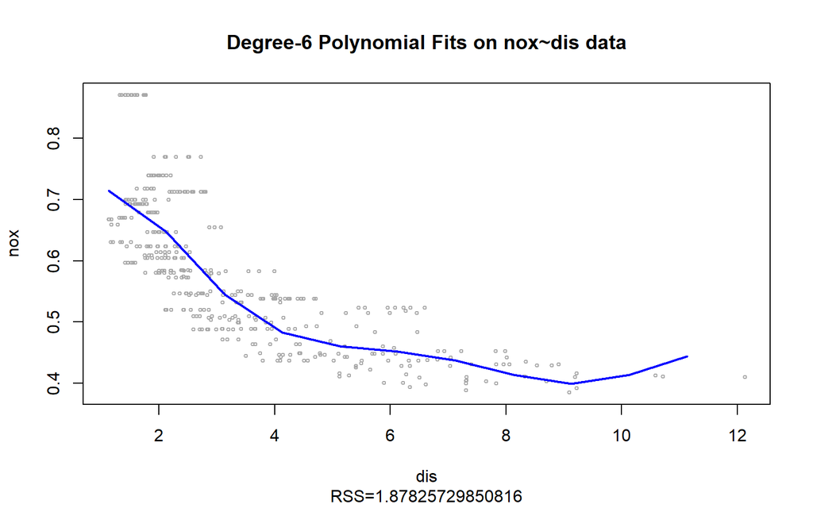

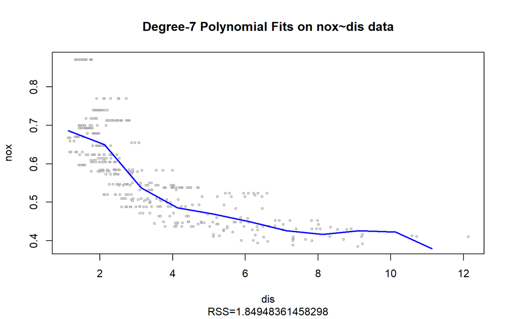

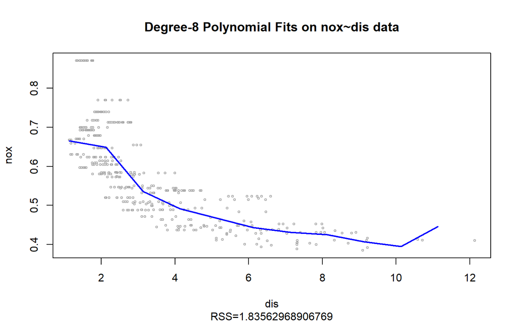

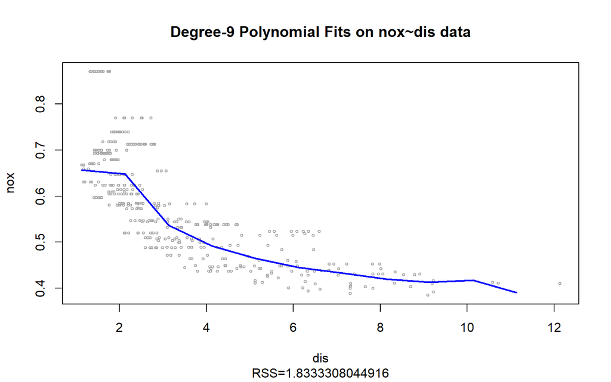

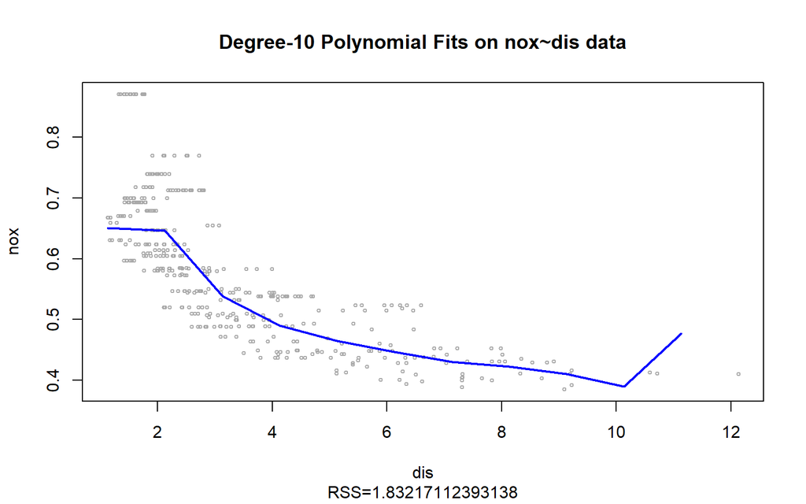

```r
for(degree in 2:10){
  poly.lm = lm(nox ~ poly(dis, degree), data=Boston)
  preds = predict(poly.lm, newdata=list(dis = dis.grid), se=TRUE)
  plot(dis, nox, xlim=dislims, cex =.5, col="darkgrey")
  title(paste0("Degree-", degree, " Polynomial Fits on nox~dis data"))
  title(sub=paste0("RSS=", sum(poly.lm$residuals^2)))
  lines(dis.grid, preds$fit, lwd=2,col="blue")
}
```

### 1.1.3 Task c)

```r
set.seed(0)
cv.error = rep(0, 10)

for (degree in 1:10){
  poly.lm = glm(nox ~ poly(dis, degree), data=Boston)
  cv.error[degree] = cv.glm(Boston, poly.lm, K=10)$delta[1]
}
cv.error
```

```
##  [1] 0.005530653 0.004075342 0.003853017 0.003895516 0.004227732
##  [6] 0.005203832 0.014311208 0.016315803 0.021706354 0.007715878
```

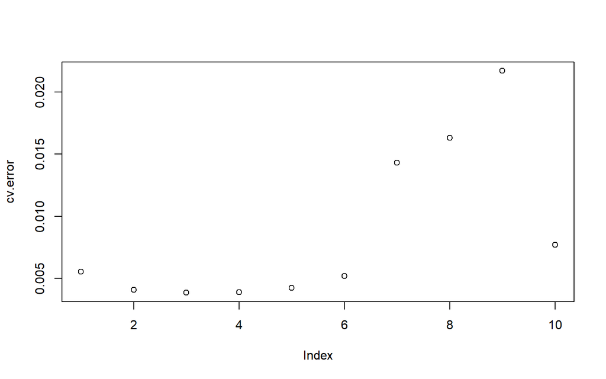

```r
plot(cv.error)
```

The models with polynomial degrees 1-6 are basically the same, though the models with polynomial degrees 2-5 are clearly the best. The models with degrees 7-9 have significantly higher cross-validation error. The model with a polynomial degree of 10 is much better than degrees 7-9, but a measure worse than models 1-6.

The model that uses the cubic polynomial yields the lowest cross-validation error at 0.003853017, so we pick that one as the best.

### 1.1.4 Task d)

Here is the output for a model using splines with four degrees of freedom. The knots were chosen automatically by `bs()` using suitable quantiles.

```r
splines.lm = lm(nox ~ bs(dis, df=4), data=Boston)
summary(splines.lm)
```

```
##
## Call:
## lm(formula = nox ~ bs(dis, df = 4), data = Boston)
##
## Residuals:
##       Min        1Q    Median        3Q       Max
## -0.124622 -0.039259 -0.008514  0.020850  0.193891
##
## Coefficients:
##                  Estimate Std. Error t value Pr(>|t|)
## (Intercept)       0.73447    0.01460  50.306  < 2e-16 ***
## bs(dis, df = 4)1 -0.05810    0.02186  -2.658  0.00812 **
## bs(dis, df = 4)2 -0.46356    0.02366 -19.596  < 2e-16 ***
## bs(dis, df = 4)3 -0.19979    0.04311  -4.634 4.58e-06 ***
## bs(dis, df = 4)4 -0.38881    0.04551  -8.544  < 2e-16 ***
## ---
## Signif. codes:  0 '***' 0.001 '**' 0.01 '*' 0.05 '.' 0.1 ' ' 1
##
## Residual standard error: 0.06195 on 501 degrees of freedom
## Multiple R-squared:  0.7164, Adjusted R-squared:  0.7142
## F-statistic: 316.5 on 4 and 501 DF,  p-value: < 2.2e-16
```

### 1.1.5 Task e)

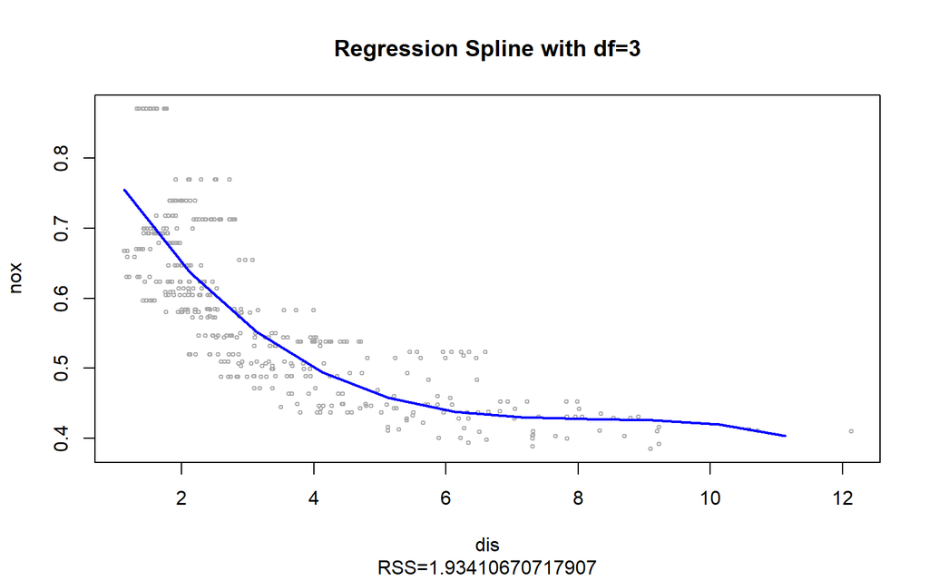

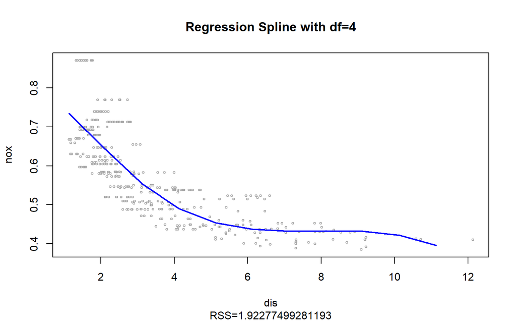

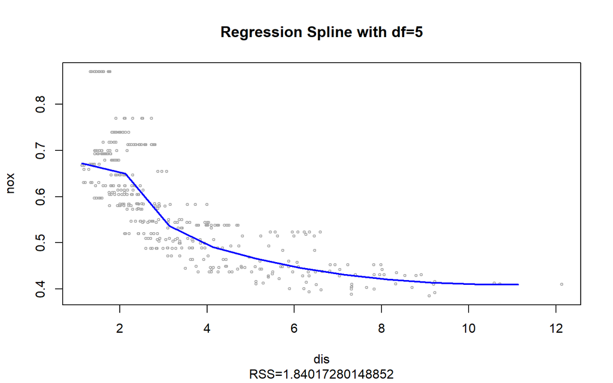

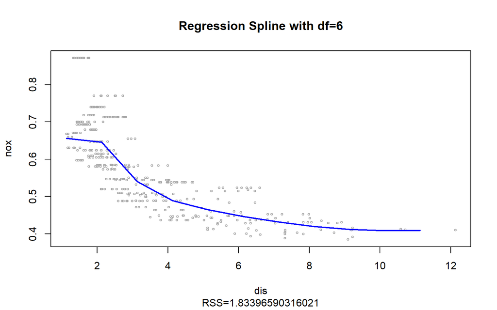

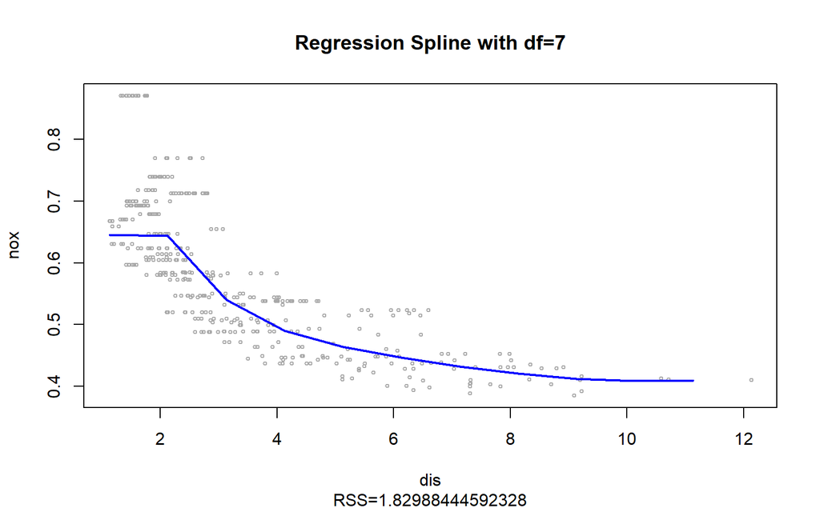

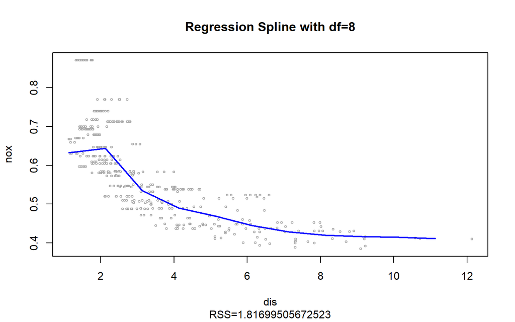

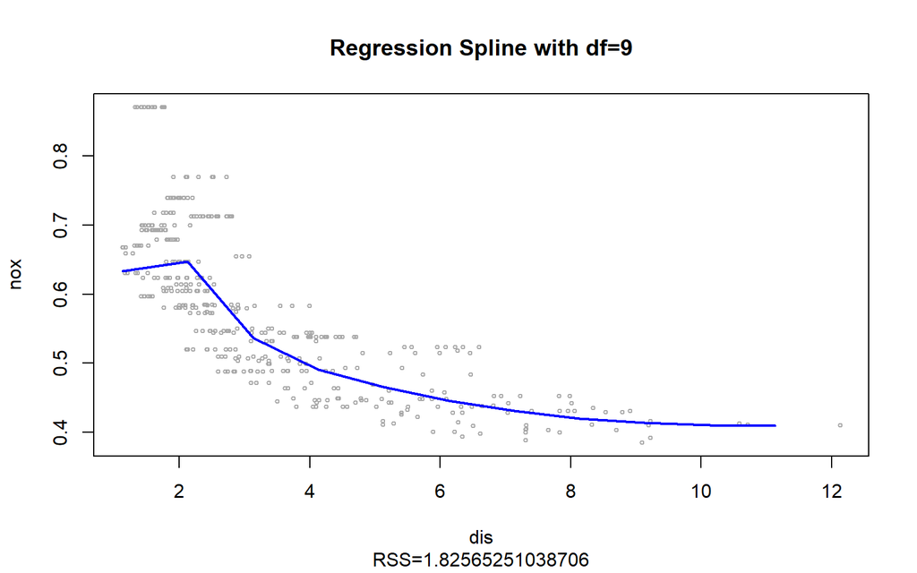

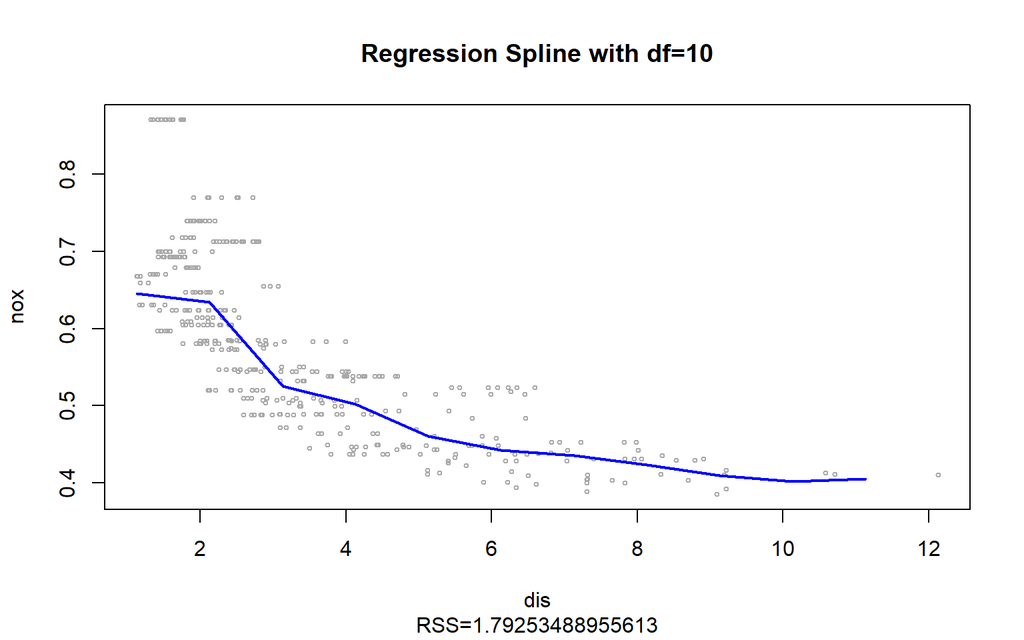

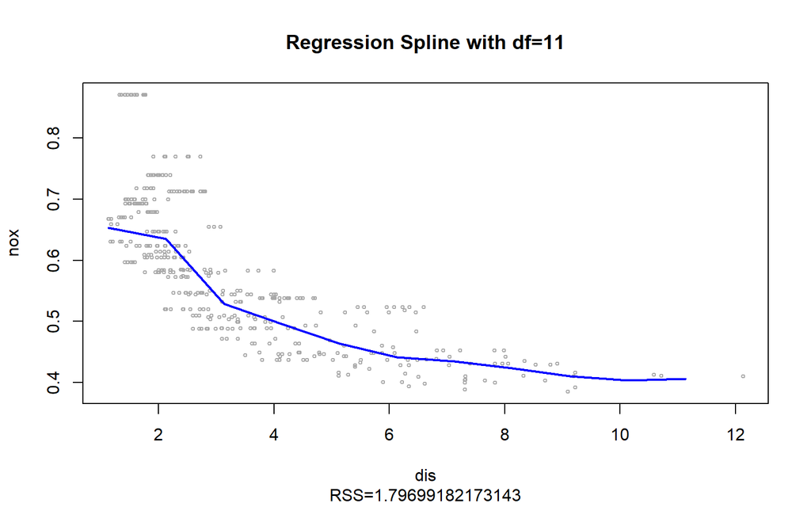

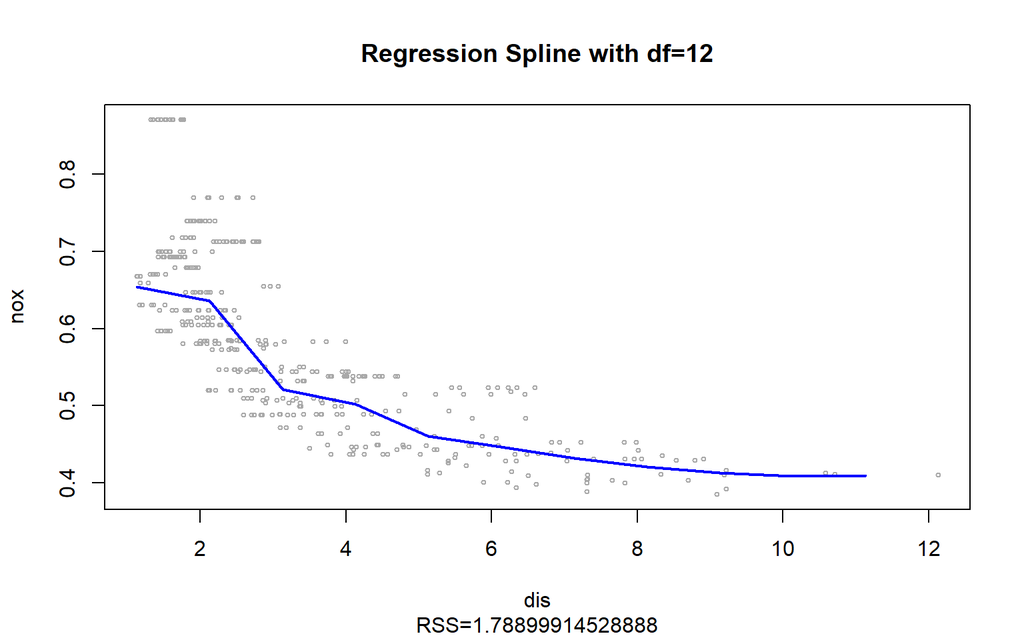

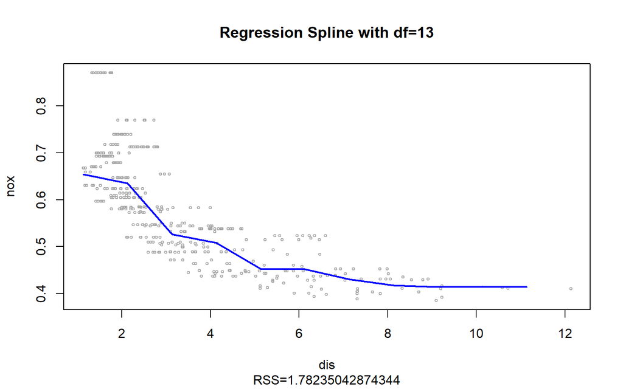

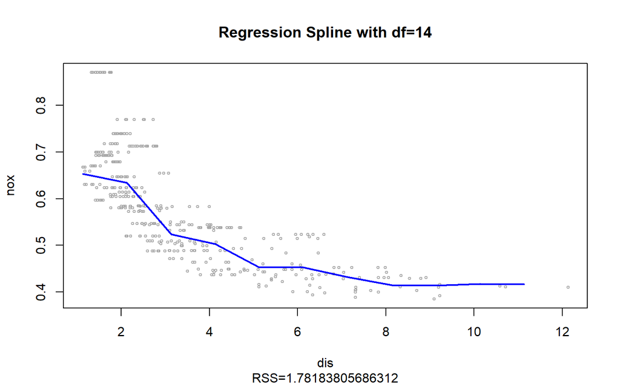

[3 more figures not shown]

```r
rss = rep(0, 15)

for(df in 3:17){
  splines.lm = lm(nox ~ bs(dis, df=df), data=Boston)
  preds = predict(splines.lm, newdata=list(dis = dis.grid), se=TRUE)
  plot(dis, nox, xlim=dislims, cex =.5, col="darkgrey")
  title(paste0("Regression Spline with df=", df))
  title(sub=paste0("RSS=", sum(splines.lm$residuals^2)))
  lines(dis.grid, preds$fit, lwd=2,col="blue")
  rss[df-2] = sum(splines.lm$residuals^2)
}
```

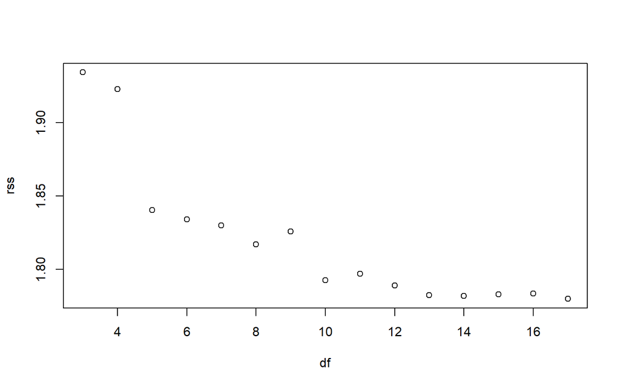

```r
df = seq(3,17)
plot(df, rss)
```

### 1.1.6 Task f)

The model with df=10 has the lowest cross-validation error at 0.003647312, so we choose that one as the best.

```r
set.seed(0)
cv.error = rep(0, 10)

for (df in 3:17){
  splines.lm = glm(nox ~ bs(dis, df=df), data=Boston)
  cv.error[df-2] = cv.glm(Boston, splines.lm, K=10)$delta[1]
}
cv.error
```

```
##  [1] 0.003865091 0.003871597 0.003678119 0.003688405 0.003736403
##  [6] 0.003689184 0.003763004 0.003647312 0.003703312 0.003714537
## [11] 0.003690434 0.003750928 0.003745098 0.003754465 0.003717022
```

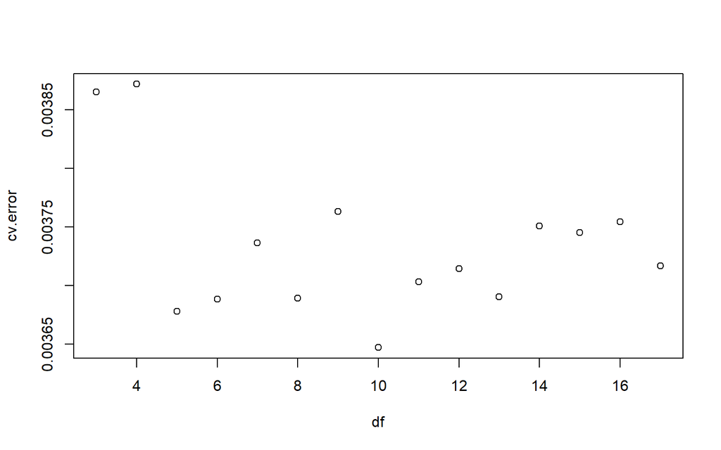

```r
df = seq(3,17,1)
plot(df, cv.error)
```

# 2 Week 7 Exercises:

## 2.1 Chapter 8 - Exercise 9

### 2.1.1 Task a)

```r
set.seed(471)

training.indices = sample(dim(OJ)[1], 800)

OJ.train = OJ[training.indices,]
OJ.test = OJ[-training.indices,]
```

### 2.1.2 Task b)

```r
tree.Purchase = tree(Purchase ~ ., OJ.train)
summary(tree.Purchase)
```

```
##
## Classification tree:
## tree(formula = Purchase ~ ., data = OJ.train)
## Variables actually used in tree construction:
## [1] "LoyalCH"   "PriceDiff"
## Number of terminal nodes:  9
## Residual mean deviance:  0.7511 = 594.1 / 791
## Misclassification error rate: 0.1762 = 141 / 800
```

This tree has 9 terminal nodes and a misclassification error rate of 141 / 800 = 17.62%.

### 2.1.3 Task c)

```r
print(tree.Purchase)
```

```
## node), split, n, deviance, yval, (yprob)
##       * denotes terminal node
##
##  1) root 800 1075.000 CH ( 0.60250 0.39750 )
##    2) LoyalCH < 0.450956 299  318.200 MM ( 0.22408 0.77592 )
##      4) LoyalCH < 0.0356415 58    0.000 MM ( 0.00000 1.00000 ) *
##      5) LoyalCH > 0.0356415 241  284.900 MM ( 0.27801 0.72199 )
##       10) PriceDiff < 0.195 120  108.100 MM ( 0.16667 0.83333 ) *
##       11) PriceDiff > 0.195 121  161.700 MM ( 0.38843 0.61157 )
##         22) LoyalCH < 0.136698 23   13.590 MM ( 0.08696 0.91304 ) *
##         23) LoyalCH > 0.136698 98  135.200 MM ( 0.45918 0.54082 ) *
##    3) LoyalCH > 0.450956 501  459.400 CH ( 0.82834 0.17166 )
##      6) LoyalCH < 0.705699 199  255.600 CH ( 0.65829 0.34171 )
##       12) PriceDiff < 0.235 95  131.400 MM ( 0.47368 0.52632 )
##         24) PriceDiff < -0.34 14    7.205 MM ( 0.07143 0.92857 ) *
##         25) PriceDiff > -0.34 81  111.700 CH ( 0.54321 0.45679 ) *
##       13) PriceDiff > 0.235 104   95.830 CH ( 0.82692 0.17308 ) *
##      7) LoyalCH > 0.705699 302  136.400 CH ( 0.94040 0.05960 )
##       14) PriceDiff < -0.39 12   16.300 CH ( 0.58333 0.41667 ) *
##       15) PriceDiff > -0.39 290  106.100 CH ( 0.95517 0.04483 ) *
```

Concerning terminal node number 24, the split criterion is having `PriceDiff` under -0.34, which classifies a purchase as being Minute Maid (`MM`). There are 14 observations in this branch, with a deviance of 7.205. Whereas 92.857% of observations in this branch are indeed Minute Maid, 7.143% of them are not.

### 2.1.4 Task d)

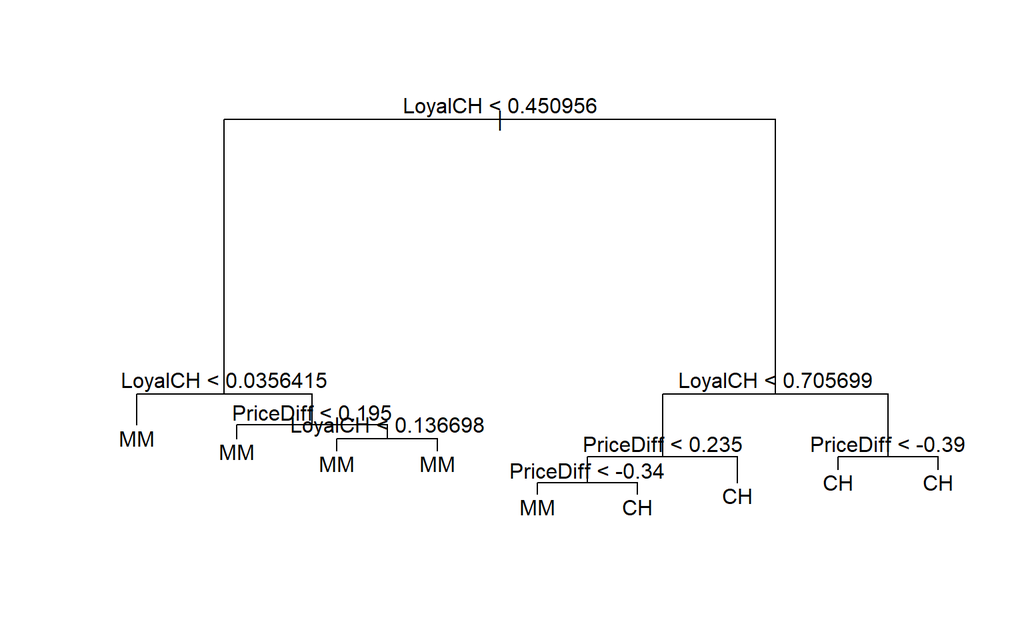

```r
plot(tree.Purchase)
text(tree.Purchase)
```

This tree relies entirely on `LoyalCH` and `PriceDiff`. The left branch solely leads to a result of `Purchase` = `MM`, and it has 4 terminal nodes. The right branch involves `PriceDiff` the most, but overall, `LoyalCH` is clearly the most important variable in this tree.

### 2.1.5 Task e)

Here we use the tree to classify the test observations and produce a confusion matrix of the results.

```r
OJ.test.pred = predict(tree.Purchase, OJ.test, type="class")
table(OJ.test$Purchase, OJ.test.pred)
```

```
##     OJ.test.pred
##       CH  MM
##   CH 153  18
##   MM  34  65
```

There is a test error rate of (34+18)/(153+18+34+65) = 19.26%.

### 2.1.6 Task f)

```r
set.seed(471)
cv.OJ = cv.tree(tree.Purchase, FUN = prune.misclass)
cv.OJ
```

```
## $size
## [1] 9 5 2 1
##
## $dev
## [1] 170 168 163 318
##
## $k
## [1] -Inf    0    4  165
##
## $method
## [1] "misclass"
##
## attr(,"class")
## [1] "prune"         "tree.sequence"
```

### 2.1.7 Task g)

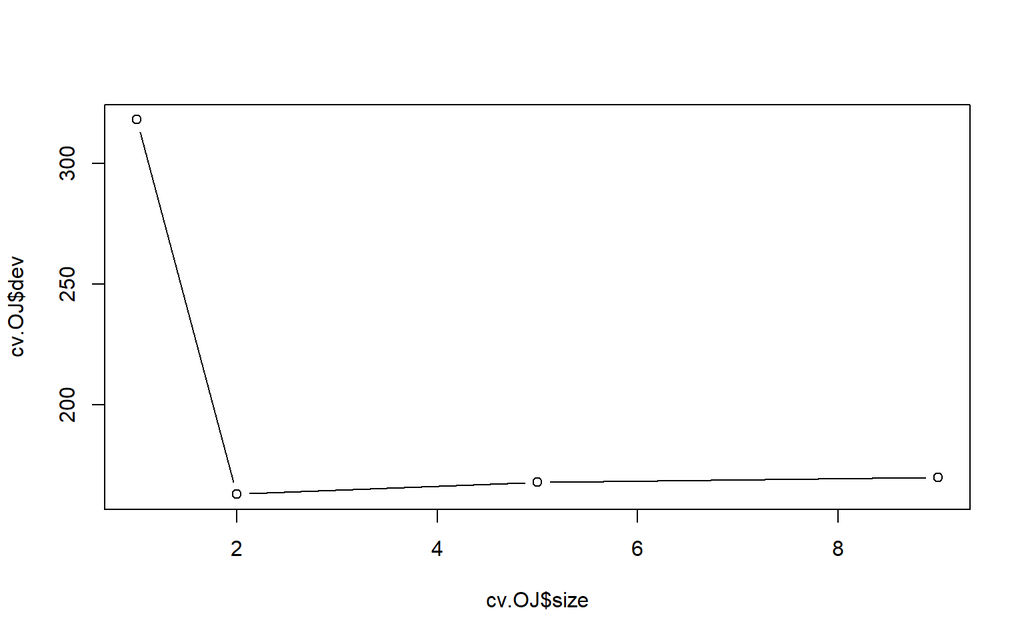

```r
plot(cv.OJ$size, cv.OJ$dev, type="b")
```

### 2.1.8 Task h)

According to these results, a tree with 2 terminal nodes results in the lowest classification error rate, with 163 classification errors.

### 2.1.9 Task i)

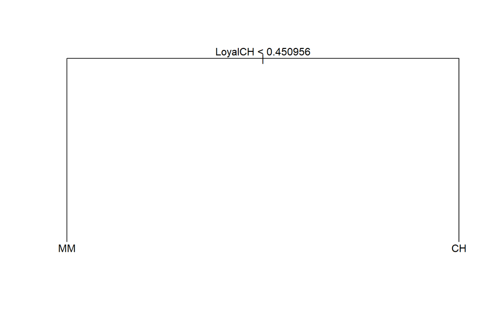

```r
prune.OJ = prune.misclass(tree.Purchase, best=2)
plot(prune.OJ)
text(prune.OJ, pretty = 0)
```

### 2.1.10 Task j)

```r
summary(prune.OJ)
```

```
##
## Classification tree:
## snip.tree(tree = tree.Purchase, nodes = 2:3)
## Variables actually used in tree construction:
## [1] "LoyalCH"
## Number of terminal nodes:  2
## Residual mean deviance:  0.9744 = 777.6 / 798
## Misclassification error rate: 0.1912 = 153 / 800
```

Whereas the unpruned tree had a training error rate of 141 / 800 = 17.62%, the pruned tree had a higher training error rate of 153 / 800 = 19.12%.

### 2.1.11 Task k)

```r
pruned.test.pred = predict(prune.OJ, OJ.test, type="class")
table(OJ.test$Purchase, pruned.test.pred)
```

```
##     pruned.test.pred
##       CH  MM
##   CH 155  16
##   MM  37  62
```

```r
round((37+16)/(155+16+37+62)*100, 2)
```

```
## [1] 19.63
```

Whereas the unpruned tree had a test error rate of 19.26%, the pruned tree had a higher test error rate of 19.63%.

Overall, it seemed that the complexity of the unpruned tree added predictive value.

# 3 Week 9 Homework: the `Khan` data set

## 3.1 Overview

We’ll use the training set to develop a favorite random forest model and a favorite tree boosting model. Then we’ll compare the two.

## 3.2 Random Forest

First, we will cycle through random forests with the hyperparameter `mtry` from 1 to 100. The output below indicates the classification error percentage for each `mtry` value from 1-100.

```r
attach(Khan)
set.seed(0)

class.err = rep(NA, 50)
for(mtry in 1:100)
{
  rf.khan = randomForest(x=xtrain, y=as.factor(ytrain), mtry=mtry)
  class.err[mtry] = sum(as.numeric(rf.khan$predicted != ytrain))/63
}
cbind(mtry=1:100, class.err)
```

```
##        mtry  class.err
##   [1,]    1 0.09523810
##   [2,]    2 0.03174603
##   [3,]    3 0.03174603
##   [4,]    4 0.01587302
##   [5,]    5 0.04761905
##   [6,]    6 0.06349206
##   [7,]    7 0.01587302
##   [8,]    8 0.00000000
##   [9,]    9 0.03174603
##  [10,]   10 0.03174603
##  [11,]   11 0.01587302
##  [12,]   12 0.01587302
##  [13,]   13 0.01587302
##  [14,]   14 0.00000000
```

[output cut: 86 more lines]

As we can see, the training data classifies perfectly when `mtry` is 8, 14, and most `mtry` values from 24 and onward.

Since there are so many candidates, we’ll perform cross-validation for each of these 100 random forests.

```r
xtrain.mtx = as.matrix(xtrain)
colnames(xtrain.mtx) = make.names(1:2308, unique=T)

ytrain.releveled = as.factor(ytrain)
levels(ytrain.releveled) <- c("Type1", "Type2", "Type3", "Type4")

cvCtrl = trainControl(method="repeatedcv", number=5, repeats=4, classProbs=TRUE)

set.seed(0)

cv.rf.khan = train(x=xtrain.mtx, y=ytrain.releveled, trControl=cvCtrl,
                   tuneGrid=data.frame(mtry=1:100), method="rf", ntree=500)
cv.rf.khan
```

```
## Random Forest
##
##   63 samples
## 2308 predictors
##    4 classes: 'Type1', 'Type2', 'Type3', 'Type4'
##
## No pre-processing
## Resampling: Cross-Validated (5 fold, repeated 4 times)
## Summary of sample sizes: 51, 49, 50, 51, 51, 52, ...
## Resampling results across tuning parameters:
##
##   mtry  Accuracy   Kappa
##     1   0.9105644  0.8709901
##     2   0.9486722  0.9265534
##     3   0.9566850  0.9380187
```

[output cut: 100 more lines]

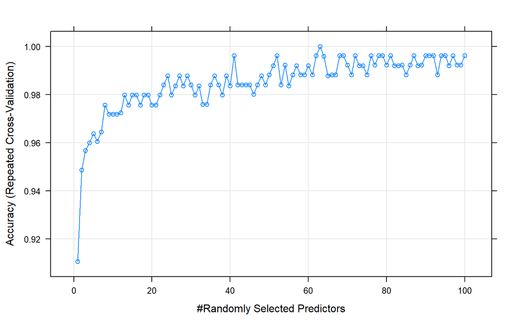

```r
plot(cv.rf.khan)
```

The models with `mtry` being 63 reported perfect accuracy with cross-validation. We therefore choose this model as our best random forest.

## 3.3 Tree Boosting

First, we’ll use the defaults of the `gbm` function arbitrarily, trying a tree-boosting model with 100 trees, an interaction depth of 1, a shrinkage of 0.001, and a minimum number of 10 observations in the terminal node. We’ll see how well it classifies the training data.

```r
train = data.frame(cbind("Y"=ytrain, xtrain.mtx))
train$Y = as.factor(train$Y)

set.seed(471)
boost.khan = gbm(Y ~ ., data=train, distribution="multinomial",
                 n.trees=100, interaction.depth=1,
                 shrinkage=0.001, n.minobsinnode = 10)

pred.probs = predict(boost.khan, train[,-1], n.trees=100, type="response")

boost.khan.pred = rep(NA,0,63)
for(x in 1:63){
  boost.khan.pred[x] = which.max(pred.probs[x,,1])
}
sum(as.numeric(as.factor(ytrain) != boost.khan.pred))/63
```

```
## [1] 0
```

This tree boosting model had zero training errors. Instead of blindly guessing and checking to see what other models might result in zero training errors, we will cross-validate this model along with other possible models.

We will go no further than an interaction depth of 1, since our first model had no training errors with an interaction depth of 1.

We will try forests of 25, 50, 100, and 150 trees. We’ll try shrinkage values of 0.0001, 0.001, 0.01, 0.1, and 0.2. We’ll use a range of minimum numbers of observations in the terminal node: 2, 5, and 10.

Displayed below is a graph of cross-validation accuracy for the different models that the `train` function tries out, followed by what the function deems the optimal model.

```r
ctr = trainControl(method="cv", number=10) ## 10-fold CV

mygrid = expand.grid(n.trees=c(25,50,100,150), interaction.depth=1,
                     shrinkage=c(0.0001,0.001,0.01,0.1,0.2),
                     n.minobsinnode=c(2, 5, 10))

set.seed(471)
boost.caret = train(x=xtrain.mtx, y=ytrain.releveled, trControl=ctr,
                    method='gbm',
                    tuneGrid=mygrid,
                    preProc=c('center','scale'), verbose=F)

boost.caret
```

```
## Stochastic Gradient Boosting
##
##   63 samples
## 2308 predictors
##    4 classes: 'Type1', 'Type2', 'Type3', 'Type4'
##
## Pre-processing: centered (2308), scaled (2308)
## Resampling: Cross-Validated (10 fold)
## Summary of sample sizes: 57, 57, 55, 57, 57, 57, ...
## Resampling results across tuning parameters:
##
##   shrinkage  n.minobsinnode  n.trees  Accuracy   Kappa
##   1e-04       2               25      1.0000000  1.0000000
##   1e-04       2               50      1.0000000  1.0000000
##   1e-04       2              100      1.0000000  1.0000000
##   1e-04       2              150      1.0000000  1.0000000
##   1e-04       5               25      1.0000000  1.0000000
##   1e-04       5               50      1.0000000  1.0000000
##   1e-04       5              100      1.0000000  1.0000000
##   1e-04       5              150      1.0000000  1.0000000
##   1e-04      10               25      1.0000000  1.0000000
##   1e-04      10               50      1.0000000  1.0000000
##   1e-04      10              100      0.9833333  0.9714286
##   1e-04      10              150      0.9833333  0.9714286
##   1e-03       2               25      1.0000000  1.0000000
##   1e-03       2               50      1.0000000  1.0000000
##   1e-03       2              100      1.0000000  1.0000000
##   1e-03       2              150      1.0000000  1.0000000
##   1e-03       5               25      1.0000000  1.0000000
##   1e-03       5               50      1.0000000  1.0000000
##   1e-03       5              100      1.0000000  1.0000000
##   1e-03       5              150      1.0000000  1.0000000
##   1e-03      10               25      0.9666667  0.9474286
##   1e-03      10               50      1.0000000  1.0000000
##   1e-03      10              100      1.0000000  1.0000000
##   1e-03      10              150      1.0000000  1.0000000
##   1e-02       2               25      1.0000000  1.0000000
##   1e-02       2               50      1.0000000  1.0000000
##   1e-02       2              100      1.0000000  1.0000000
##   1e-02       2              150      1.0000000  1.0000000
```

[output cut: 22 more lines]

```
##   2e-01       2              100      1.0000000  1.0000000
##   2e-01       2              150      1.0000000  1.0000000
##   2e-01       5               25      1.0000000  1.0000000
##   2e-01       5               50      1.0000000  1.0000000
##   2e-01       5              100      1.0000000  1.0000000
##   2e-01       5              150      1.0000000  1.0000000
##   2e-01      10               25      1.0000000  1.0000000
##   2e-01      10               50      0.9833333  0.9769231
##   2e-01      10              100      1.0000000  1.0000000
##   2e-01      10              150      1.0000000  1.0000000
##
## Tuning parameter 'interaction.depth' was held constant at a value of 1
## Accuracy was used to select the optimal model using the largest value.
## The final values used for the model were n.trees = 25, interaction.depth
##  = 1, shrinkage = 1e-04 and n.minobsinnode = 2.
```

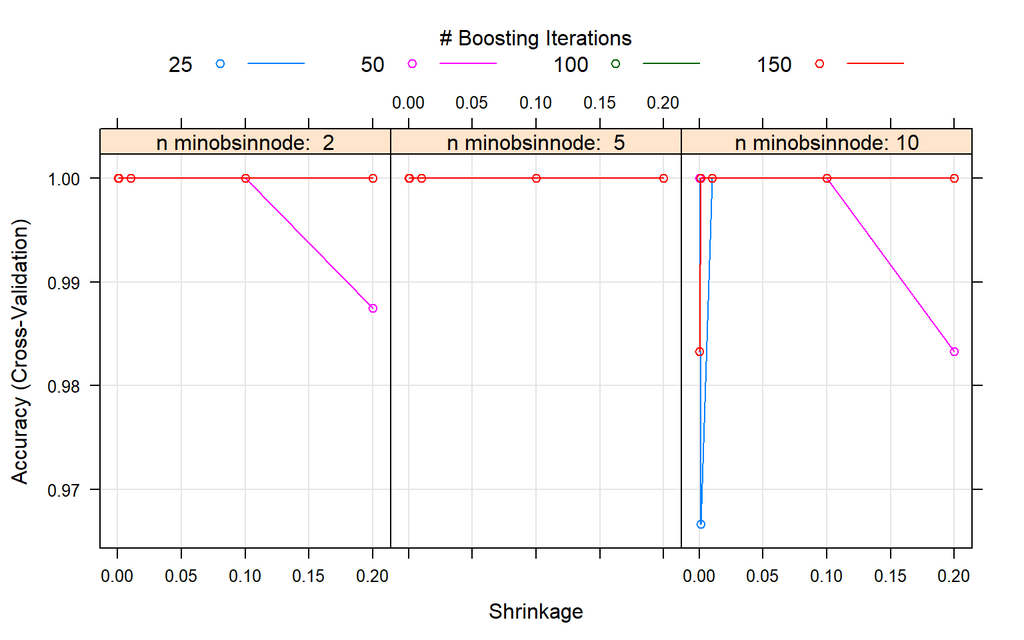

```r
plot(boost.caret)
```

```r
boost.caret$bestTune
```

|  | n.trees | interaction.depth | shrinkage | n.minobsinnode |
| --- | --- | --- | --- | --- |
| 1 | 25 | 1 | 1e-04 | 2 |

We see that the vast majority of tree boosting models had perfect validation accuracy, and the procedure chose the smallest possible hyperparameters as the best model! We’ll run cross-validation again with even smaller hyperparameter choices.

```r
mygrid = expand.grid(n.trees=c(1,2,5,25,50), interaction.depth=1,
                     shrinkage=c(0.00001,0.0001,0.001,0.01),
                     n.minobsinnode=c(1,2))

set.seed(471)
boost.caret = train(x=xtrain.mtx, y=ytrain.releveled, trControl=ctr,
                    method='gbm',
                    tuneGrid=mygrid,
                    preProc=c('center','scale'), verbose=F)

boost.caret
```

```
## Stochastic Gradient Boosting
##
##   63 samples
## 2308 predictors
##    4 classes: 'Type1', 'Type2', 'Type3', 'Type4'
##
## Pre-processing: centered (2308), scaled (2308)
## Resampling: Cross-Validated (10 fold)
## Summary of sample sizes: 57, 57, 55, 57, 57, 57, ...
## Resampling results across tuning parameters:
##
##   shrinkage  n.minobsinnode  n.trees  Accuracy   Kappa
##   1e-05      1                1       0.7288095  0.6363637
##   1e-05      1                2       0.8232143  0.7593993
##   1e-05      1                5       0.9833333  0.9777778
##   1e-05      1               25       1.0000000  1.0000000
##   1e-05      1               50       1.0000000  1.0000000
##   1e-05      2                1       0.6797619  0.5762996
##   1e-05      2                2       0.8398810  0.7769414
##   1e-05      2                5       0.9833333  0.9769231
##   1e-05      2               25       1.0000000  1.0000000
##   1e-05      2               50       1.0000000  1.0000000
##   1e-04      1                1       0.6915476  0.5988390
##   1e-04      1                2       0.9157143  0.8800165
##   1e-04      1                5       1.0000000  1.0000000
##   1e-04      1               25       1.0000000  1.0000000
##   1e-04      1               50       1.0000000  1.0000000
##   1e-04      2                1       0.6504762  0.5355048
##   1e-04      2                2       0.8055952  0.7288221
##   1e-04      2                5       0.9375000  0.9127778
##   1e-04      2               25       1.0000000  1.0000000
##   1e-04      2               50       1.0000000  1.0000000
##   1e-03      1                1       0.6644048  0.5463350
##   1e-03      1                2       0.8696429  0.8176147
##   1e-03      1                5       0.9416667  0.9183372
##   1e-03      1               25       1.0000000  1.0000000
##   1e-03      1               50       1.0000000  1.0000000
##   1e-03      2                1       0.6879762  0.5888138
##   1e-03      2                2       0.8555952  0.7970937
##   1e-03      2                5       0.9833333  0.9777778
##   1e-03      2               25       1.0000000  1.0000000
##   1e-03      2               50       1.0000000  1.0000000
##   1e-02      1                1       0.8522619  0.8025455
##   1e-02      1                2       0.9014286  0.8660837
##   1e-02      1                5       0.9541667  0.9360000
##   1e-02      1               25       1.0000000  1.0000000
##   1e-02      1               50       1.0000000  1.0000000
##   1e-02      2                1       0.6826190  0.5772477
##   1e-02      2                2       0.8841667  0.8394219
##   1e-02      2                5       0.9833333  0.9777778
##   1e-02      2               25       1.0000000  1.0000000
##   1e-02      2               50       1.0000000  1.0000000
##
## Tuning parameter 'interaction.depth' was held constant at a value of 1
## Accuracy was used to select the optimal model using the largest value.
## The final values used for the model were n.trees = 5, interaction.depth
##  = 1, shrinkage = 1e-04 and n.minobsinnode = 1.
```

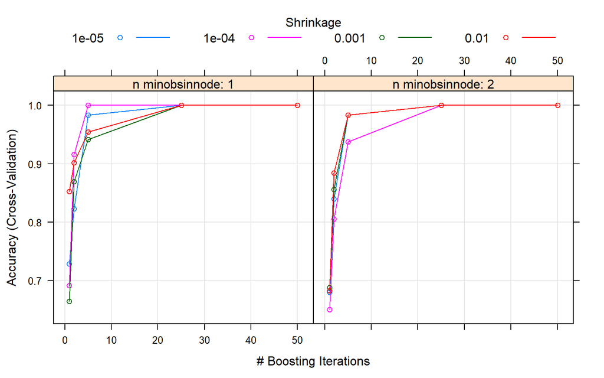

```r
plot(boost.caret)
```

```r
boost.caret$bestTune
```

|  | n.trees | interaction.depth | shrinkage | n.minobsinnode |
| --- | --- | --- | --- | --- |
| 13 | 5 | 1 | 1e-04 | 1 |

We’ll do one more round of cross-validation to really fine-tune these hyperparameters to get the simplest model that has perfect cross-validation accuracy.

```r
mygrid = expand.grid(n.trees=c(1,2,3,4,5), interaction.depth=1,
                     shrinkage=c(0.00005,0.000075,0.0001,0.0005),
                     n.minobsinnode=1)

set.seed(471)
boost.caret = train(x=xtrain.mtx, y=ytrain.releveled, trControl=ctr,
                    method='gbm',
                    tuneGrid=mygrid,
                    preProc=c('center','scale'), verbose=F)

boost.caret
```

```
## Stochastic Gradient Boosting
##
##   63 samples
## 2308 predictors
##    4 classes: 'Type1', 'Type2', 'Type3', 'Type4'
##
## Pre-processing: centered (2308), scaled (2308)
## Resampling: Cross-Validated (10 fold)
## Summary of sample sizes: 57, 57, 55, 57, 57, 57, ...
## Resampling results across tuning parameters:
##
##   shrinkage  n.trees  Accuracy   Kappa
##   5.0e-05    1        0.7180952  0.6234866
##   5.0e-05    2        0.9240476  0.8923007
##   5.0e-05    3        0.9675000  0.9517287
##   5.0e-05    4        0.9875000  0.9829787
##   5.0e-05    5        0.9875000  0.9829787
##   7.5e-05    1        0.7230952  0.6193857
##   7.5e-05    2        0.8355952  0.7712137
##   7.5e-05    3        0.9107143  0.8752603
##   7.5e-05    4        0.9232143  0.8919231
##   7.5e-05    5        0.9232143  0.8910684
##   1.0e-04    1        0.8240476  0.7579575
##   1.0e-04    2        0.9175000  0.8863398
##   1.0e-04    3        0.9800000  0.9705882
##   1.0e-04    4        1.0000000  1.0000000
##   1.0e-04    5        0.9875000  0.9822222
##   5.0e-04    1        0.8058333  0.7344350
##   5.0e-04    2        0.9300000  0.8985278
##   5.0e-04    3        0.9633333  0.9456731
##   5.0e-04    4        0.9800000  0.9687500
##   5.0e-04    5        0.9800000  0.9687500
##
## Tuning parameter 'interaction.depth' was held constant at a value of
##  1
## Tuning parameter 'n.minobsinnode' was held constant at a value of 1
## Accuracy was used to select the optimal model using the largest value.
## The final values used for the model were n.trees = 4, interaction.depth
##  = 1, shrinkage = 1e-04 and n.minobsinnode = 1.
```

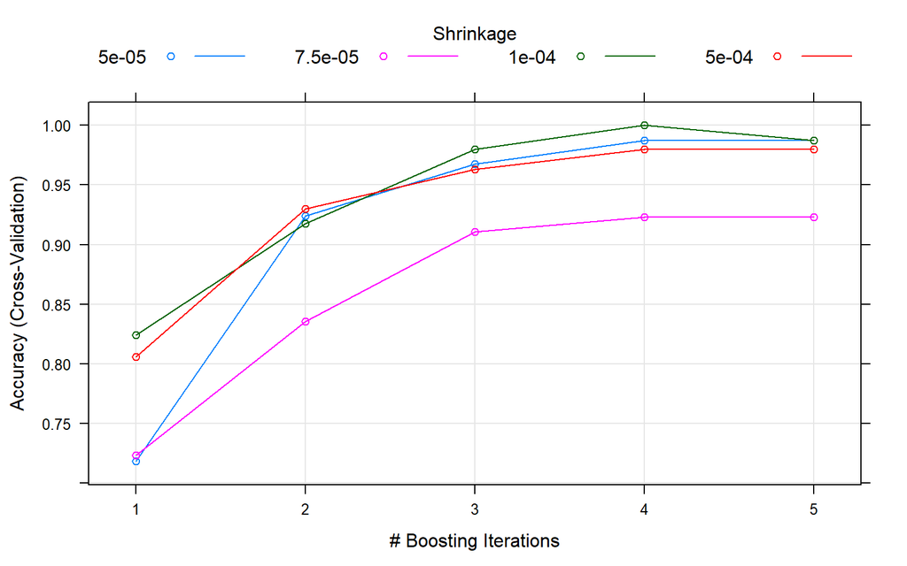

```r
plot(boost.caret)
```

```r
boost.caret$bestTune
```

|  | n.trees | interaction.depth | shrinkage | n.minobsinnode |
| --- | --- | --- | --- | --- |
| 14 | 4 | 1 | 1e-04 | 1 |

We’ve finally arrived at a result that is cleary superior to all simpler models. We will select the hyperparameters above as our best tree boosting model.

## 3.4 Test error of each model

Here we compute the number of test errors for our cross-validated random forest model with `mtry` = 63.

Below is the number of test errors followed by a table of the actual and predicted values as a sanity check.

```r
rf.test.pred = predict(cv.rf.khan$finalModel, xtest)

sum(as.numeric(as.numeric(rf.test.pred) != ytest))
```

```
## [1] 2
```

```r
cbind(ytest, rf.test.pred)
```

```
##     ytest rf.test.pred
## V1      3            3
## V2      2            2
## V4      4            4
## V6      2            2
## V7      1            1
## V8      3            3
## V10     4            4
## V12     2            2
## V14     3            3
## V15     1            1
## V16     3            3
## V17     4            4
## V18     1            1
## V19     2            2
## V20     2            2
## V21     2            2
## V22     4            4
## V23     3            4
## V24     4            4
## V25     3            4
```

There were 2 test errors, for a test error rate of 2/20 = 10%.

Now we’ll compute the number of test errors for our cross-validated random forest boosting model.

Again, below is the number of test errors followed by a table of the actual and predicted values as a sanity check.

```r
boost.test.probs = predict(boost.caret$finalModel, xtest, type="response",
                           n.trees=boost.caret$finalModel$n.trees)
boost.test.pred  = rep(NA,0,20)
for(x in 1:20){
  boost.test.pred[x] = which.max(boost.test.probs[x,,1])
}

sum(as.numeric(ytest != boost.test.pred))
```

```
## [1] 3
```

```r
cbind(ytest, boost.test.pred)
```

```
##       ytest boost.test.pred
##  [1,]     3               1
##  [2,]     2               1
##  [3,]     4               4
##  [4,]     2               2
##  [5,]     1               1
##  [6,]     3               3
##  [7,]     4               4
##  [8,]     2               2
##  [9,]     3               3
## [10,]     1               1
## [11,]     3               3
## [12,]     4               4
## [13,]     1               1
## [14,]     2               2
## [15,]     2               1
## [16,]     2               2
## [17,]     4               4
## [18,]     3               3
## [19,]     4               4
## [20,]     3               3
```

There were 3 testing errors, meaning that our final boosting model had a test error rate of 3/20 = 15%, as opposed to our random forest’s test error rate of 2/20 = 10%.

Therefore, our best model is our random forest with the hyperparameter `mtry` equal to 63.

# 4 Week 10 homework

## 4.1 Chapter 9 - Exercise 8

### 4.1.1 Task a)

```r
set.seed(2018)

training.indices = sample(dim(OJ)[1], 800)

OJ.train = OJ[training.indices,]
OJ.test = OJ[-training.indices,]
```

### 4.1.2 Task b)

```r
svm.OJ = svm(Purchase ~ ., OJ.train, kernel ="linear", cost=0.01, scale=F)
summary(svm.OJ)
```

```
##
## Call:
## svm(formula = Purchase ~ ., data = OJ.train, kernel = "linear",
##     cost = 0.01, scale = F)
##
##
## Parameters:
##    SVM-Type:  C-classification
##  SVM-Kernel:  linear
##        cost:  0.01
##       gamma:  0.05555556
##
## Number of Support Vectors:  616
##
##  ( 309 307 )
##
##
## Number of Classes:  2
##
## Levels:
##  CH MM
```

The summary tells us that a linear kernel was used with `cost=0.01` and `gamma=0.05555556`. There are 616 support vectors: 309 in the CH level and 307 in MM.

### 4.1.3 Task c)

```r
svm.train.pred = predict(svm.OJ, OJ.train)
sum(as.numeric(OJ.train$Purchase != svm.train.pred))/nrow(OJ.train)
```

```
## [1] 0.2925
```

The training error rate is 29.25%.

```r
svm.test.pred  = predict(svm.OJ, OJ.test)
sum(as.numeric(OJ.test$Purchase != svm.test.pred))/nrow(OJ.test)
```

```
## [1] 0.3074074
```

The test error rate is slightly worse at 30.74074%.

### 4.1.4 Task d)

```r
set.seed(2018)
OJ.svm.tune = tune(svm, Purchase ~ ., data=OJ.train, kernel = "linear",
     ranges=list(cost=c(0.001, 0.01, 0.1, 1, 5, 10)))
OJ.svm.tune
```

```
##
## Parameter tuning of 'svm':
##
## - sampling method: 10-fold cross validation
##
## - best parameters:
##  cost
##   0.1
##
## - best performance: 0.1625
```

The optimal cost turns out to be 0.1.

### 4.1.5 Task e)

```r
svm.train.pred = predict(OJ.svm.tune$best.model, OJ.train)
sum(as.numeric(OJ.train$Purchase != svm.train.pred))/nrow(OJ.train)
```

```
## [1] 0.1575
```

With `cost=0.1`, the training error rate has improved to 15.75%

```r
svm.test.pred  = predict(OJ.svm.tune$best.model, OJ.test)
test.err.linear = sum(as.numeric(OJ.test$Purchase != svm.test.pred))/nrow(OJ.test)
test.err.linear
```

```
## [1] 0.1703704
```

The test error rate also improved to 17.03704%.

### 4.1.6 Task f)

```r
svm.OJ = svm(Purchase ~ ., OJ.train, kernel="radial", cost=0.01, scale=F)
summary(svm.OJ)
```

```
##
## Call:
## svm(formula = Purchase ~ ., data = OJ.train, kernel = "radial",
##     cost = 0.01, scale = F)
##
##
## Parameters:
##    SVM-Type:  C-classification
##  SVM-Kernel:  radial
##        cost:  0.01
##       gamma:  0.05555556
##
## Number of Support Vectors:  627
##
##  ( 320 307 )
##
##
## Number of Classes:  2
##
## Levels:
##  CH MM
```

The summary tells us that a radial kernel was used with `cost=0.01` and `gamma=0.05555556`. There are 627 support vectors: 320 in the CH level and 307 in MM.

```r
svm.train.pred = predict(svm.OJ, OJ.train)
sum(as.numeric(OJ.train$Purchase != svm.train.pred))/nrow(OJ.train)
```

```
## [1] 0.38375
```

The training error rate is 38.375%.

```r
svm.test.pred  = predict(svm.OJ, OJ.test)
sum(as.numeric(OJ.test$Purchase != svm.test.pred))/nrow(OJ.test)
```

```
## [1] 0.4074074
```

The test error rate is slightly worse at 40.74074%.

```r
set.seed(2018)
OJ.svm.tune = tune(svm, Purchase ~ ., data=OJ.train, kernel = "radial",
     ranges=list(cost=c(0.001, 0.01, 0.1, 1, 5, 10)))
OJ.svm.tune
```

```
##
## Parameter tuning of 'svm':
##
## - sampling method: 10-fold cross validation
##
## - best parameters:
##  cost
##     1
##
## - best performance: 0.1775
```

The optimal cost turns out to be 1.

```r
svm.train.pred = predict(OJ.svm.tune$best.model, OJ.train)
sum(as.numeric(OJ.train$Purchase != svm.train.pred))/nrow(OJ.train)
```

```
## [1] 0.1425
```

With `cost=1`, the training error rate has improved to 14.25%

```r
svm.test.pred  = predict(OJ.svm.tune$best.model, OJ.test)
test.err.radial = sum(as.numeric(OJ.test$Purchase != svm.test.pred))/nrow(OJ.test)
test.err.radial
```

```
## [1] 0.1740741
```

The test error rate also improved to 17.40741%.

### 4.1.7 Task g)

```r
svm.OJ = svm(Purchase ~ ., OJ.train, kernel="polynomial", cost=0.01, degree=2, scale=F)
summary(svm.OJ)
```

```
##
## Call:
## svm(formula = Purchase ~ ., data = OJ.train, kernel = "polynomial",
##     cost = 0.01, degree = 2, scale = F)
##
##
## Parameters:
##    SVM-Type:  C-classification
##  SVM-Kernel:  polynomial
##        cost:  0.01
##      degree:  2
##       gamma:  0.05555556
##      coef.0:  0
##
## Number of Support Vectors:  344
##
##  ( 173 171 )
##
##
## Number of Classes:  2
##
## Levels:
##  CH MM
```

The summary tells us that a polynomial kernel was used with `cost=0.01` and `gamma=0.05555556`. There are 344 support vectors: 173 in the CH level and 171 in MM.

```r
svm.train.pred = predict(svm.OJ, OJ.train)
sum(as.numeric(OJ.train$Purchase != svm.train.pred))/nrow(OJ.train)
```

```
## [1] 0.15875
```

The training error rate is 15.875%.

```r
svm.test.pred  = predict(svm.OJ, OJ.test)
sum(as.numeric(OJ.test$Purchase != svm.test.pred))/nrow(OJ.test)
```

```
## [1] 0.1703704
```

The test error rate is slightly worse at 17.03704%.

```r
set.seed(2018)
OJ.svm.tune = tune(svm, Purchase ~ ., data=OJ.train, kernel = "polynomial", degree=2,
     ranges=list(cost=c(0.001, 0.01, 0.1, 1, 5, 10)))
OJ.svm.tune
```

```
##
## Parameter tuning of 'svm':
##
## - sampling method: 10-fold cross validation
##
## - best parameters:
##  cost
##    10
##
## - best performance: 0.175
```

The optimal cost turns out to be 10.

```r
svm.train.pred = predict(OJ.svm.tune$best.model, OJ.train)
sum(as.numeric(OJ.train$Purchase != svm.train.pred))/nrow(OJ.train)
```

```
## [1] 0.14375
```

With `cost=10`, the training error rate has improved to 14.375%

```r
svm.test.pred  = predict(OJ.svm.tune$best.model, OJ.test)
test.err.poly = sum(as.numeric(OJ.test$Purchase != svm.test.pred))/nrow(OJ.test)
test.err.poly
```

```
## [1] 0.1814815
```

### 4.1.8 Task h)

We should really only care about the test error rates after the cost parameter was chosen through cross-validation:

```r
cbind(Kernel = c("Linear", "Radial", "Polynomial"),
      Test.error.rate = c(paste0(round(test.err.linear*100, 2),"%"),
                          paste0(round(test.err.radial*100, 2),"%"),
                          paste0(round(test.err.poly*100, 2),"%")))
```

```
##      Kernel       Test.error.rate
## [1,] "Linear"     "17.04%"
## [2,] "Radial"     "17.41%"
## [3,] "Polynomial" "18.15%"
```

Therefore, the linear kernel gave us the best results for these data.

Nik Krieger

2018-04-10